# Lecture 13 examples

Allison Horst

3/1/2020

Read in mock logistic growth data:

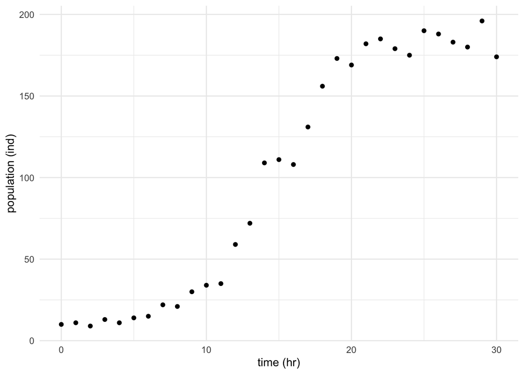

```r
df <- read_csv(here("data", "log_growth.csv"))

# Look at it:
ggplot(data = df, aes(x = time, y = pop)) +
  geom_point() +
  theme_minimal() +
  labs(x = "time (hr)", y = "population (ind)")
```

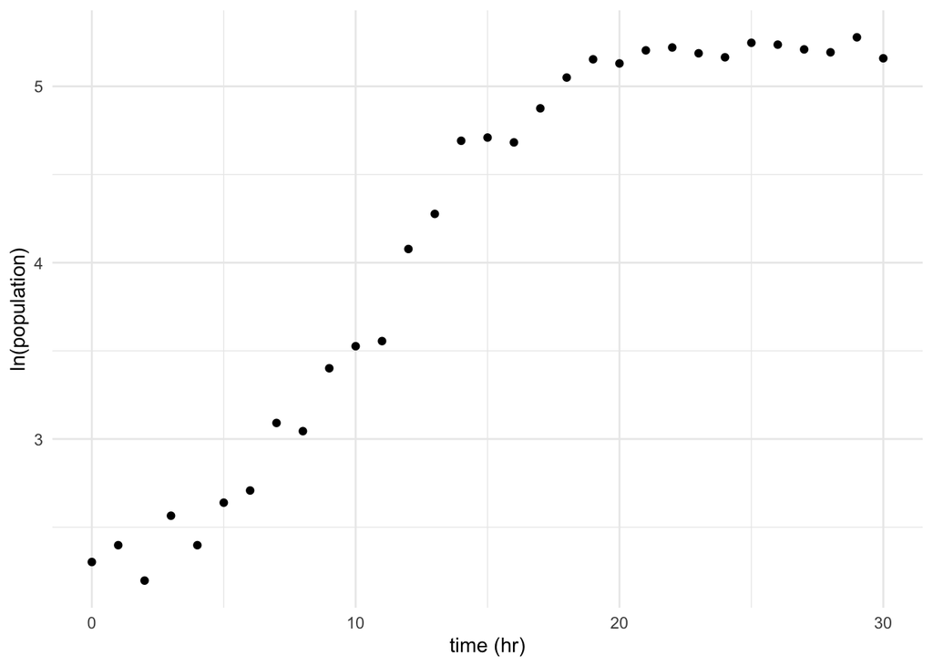

```r
# Look at the log transformed:
ggplot(data = df, aes(x = time, y = log(pop))) +
  geom_point() +
  theme_minimal() +
  labs(x = "time (hr)", y = "ln(population)")
```

Recall:

$P(t)=\frac{K}{1+Ae^{-kt}}$, where

- $K$ is the carrying capacity
- $A$ is $\frac{K-P_0}{P_0}$
- $k$ is the growth rate constant

### Initial estimates for *K*, *A* and *k*

Estimate the growth constant during exponential phase (to get a starting-point guess for *k*):

```r
# Get only up to 14 hours & ln transform pop
df_exp <- df %>%
  filter(time < 15) %>%
  mutate(ln_pop = log(pop))

# Model linear to get *k* estimate:
lm_k <- lm(ln_pop ~ time, data = df_exp)
lm_k
```

```
##
## Call:
## lm(formula = ln_pop ~ time, data = df_exp)
##
## Coefficients:
## (Intercept)         time
##      1.9597       0.1664
```

```r
# Coefficient (k) ~ 0.17
```

Two methods we’ll try to estimate the parameters: nonlinear least squares (NLS) and Maximum Likelihood Estimation (MLE).

### Nonlinear least squares

Nonlinear least squares converges on parameter estimates that minimize the the sum of squares of residuals through an iterative algorithm (we’ll use Gauss-Newton, the most common).

Check out the `stats::nls()` function (`?nls`) for more information.

Now enter our model information, with a list of estimated starting parameter values:

```r
df_nls <- nls(pop ~ K/(1 + A*exp(-r*time)),
              data = df,
              start = list(K = 180, A = 1.7, r = 0.17)
              )

# Note: you can add argument `trace = TRUE` to see the different estimates at each iteration (and the left-most column reported tells you SSE)

summary(df_nls)
```

```
##
## Formula: pop ~ K/(1 + A * exp(-r * time))
##
## Parameters:
##    Estimate Std. Error t value Pr(>|t|)
## K 188.70031    3.36708  56.043  < 2e-16 ***
## A 138.85588   44.94809   3.089   0.0045 **
## r   0.35043    0.02447  14.323 2.06e-14 ***
## ---
## Signif. codes:  0 '***' 0.001 '**' 0.01 '*' 0.05 '.' 0.1 ' ' 1
##
## Residual standard error: 8.456 on 28 degrees of freedom
##
## Number of iterations to convergence: 13
## Achieved convergence tolerance: 2.861e-06
```

Our model with estimated parameters is:
$$P(t) = \frac{188.70}{1+138.86e^{-0.35t}}$$

### Visualize model

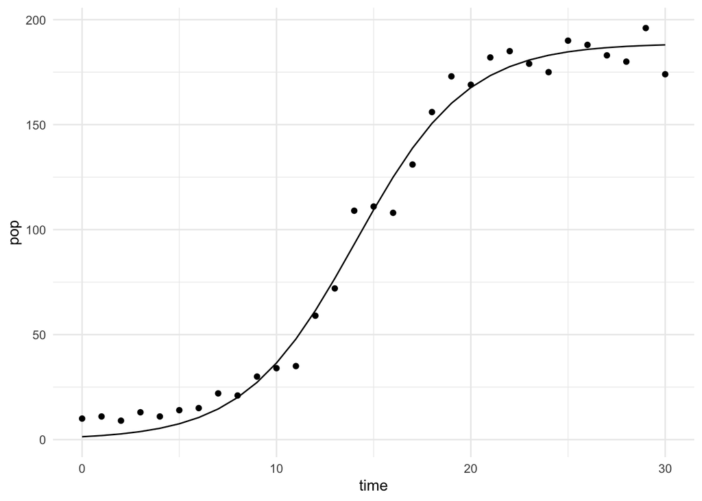

```r
t_seq <- seq(from = 0, to = 35, length = 200)

# Make predictions for the population at all of those times (t)
p_predict <- predict(df_nls, newdata = t_seq)

# Bind predictions to original data frame:
df_complete <- data.frame(df, p_predict)

# Plot them all together:
ggplot(data = df_complete, aes(x = time, y = pop)) +
  geom_point() +
  geom_line(aes(x = time, y = p_predict)) +
  theme_minimal()
```

### Find confidence intervals for parameter estimates

See `?confint2` and `?confint.nls`

```r
df_ci <- confint2(df_nls)
df_ci
```

```
##         2.5 %      97.5 %
## K 181.8031528 195.5974682
## A  46.7838834 230.9278693
## r   0.3003161   0.4005515
```

### Bootstrap samples, visualize CI

A great resource: [`broom` vignette on bootstrapping from `nls`](https://cran.r-project.org/web/packages/broom/vignettes/bootstrapping.html)

```r
set.seed(1983)
df_boot <- bootstraps(df, times = 100)
df_boot
```

```
## # Bootstrap sampling
## # A tibble: 100 x 2
##    splits          id
##    <list>          <chr>
##  1 <split [31/11]> Bootstrap001
##  2 <split [31/13]> Bootstrap002
##  3 <split [31/12]> Bootstrap003
##  4 <split [31/12]> Bootstrap004
##  5 <split [31/13]> Bootstrap005
##  6 <split [31/9]>  Bootstrap006
##  7 <split [31/9]>  Bootstrap007
##  8 <split [31/10]> Bootstrap008
##  9 <split [31/9]>  Bootstrap009
## 10 <split [31/11]> Bootstrap010
## # … with 90 more rows
```